# Tkinter

Tkinter is a Python interface to the Tk GUI library and has been a part of the Python standard library since 1994 with the release of Python version 1.1, making it the defacto GUI library for Python.

## What are Widgets?

Widgets in Tkinter are the elements of GUI application which provides various controls (such as Labels, Buttons, ComboBoxes, CheckBoxes, MenuBars, RadioButtons and many more) to users to interact with the application.

## Creating a Tkinter Hello World

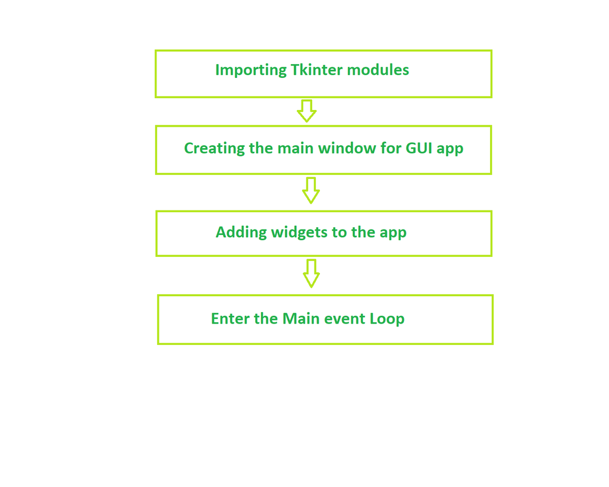

1. Every Tkinter program must have exactly one root window, which represents the top-level window of our application. The root window is an instance of the Tk class. We create it by calling Tk() as we've done here. This object must exist before we can create any other Tkinter objects, and when it is destroyed, the application quits.
2. The first argument to any Tkinter widget is always the parent widget (sometimes called master widget); in this case, we've passed in a reference to our root window.
3. We need to place the widgets on the GUI using a geometry manager method such as pack() method. The widget will be attached to its parent widget, and drawn there.
4. The last line in any Tkinter program is to start the application's event loop. The event loop is an infinite loop that continually processes any events that happen during the execution of the program. Events can be things like keystrokes, mouse clicks, or other user-generated activity. This loop runs until the program exits, so any code after this line will not be run until the main window is closed.

```python
import tkinter as tk

root = tk.Tk() #create root window
label = tk.Label(root, text="Hello World") #add label widget to the parent which is the root window
label.pack()
root.mainloop()
```

## Widget classes

#### Labels

Label widgets are used to display text or images. The text displayed by a Label widget can’t be edited by the user. It’s for display purposes only.

```python
import tkinter as tk
root = tk.Tk()
root.title("Testing Widgets")
tk.Label(root,text="Hello, Tkinter",
    foreground="white",  # Set the text color to white
    background="black",  # Set the background color to black
    width=10,
    height=10).pack()
root.mainloop()
```

#### Buttons

Button widgets are used to display clickable buttons. You can configure them to call a function whenever they’re clicked.

```python
import tkinter as tk
root = tk.Tk()
root.title("Testig Widgets")
tk.Button(root,
    text="Click me!",
    width=25,
    height=5,
    bg="blue",
    fg="yellow").pack()
root.mainloop()
```

#### Entry

When you need to get a little bit of text from a user, like a name or an email address, use an Entry widget. It’ll display a small text box that the user can type some text into.

```python
import tkinter as tk
root = tk.Tk()
root.title("Testing Widgets")
tk.Entry(root,fg="red", bg="white", width=50).pack()
root.mainloop()
```

#### Text

Text widgets are used for entering text, just like Entry widgets. The difference is that Text widgets may contain multiple lines of text.

```python
import tkinter as tk
root = tk.Tk()
root.title("Testing Widgets")
tk.Text(root,fg="red", bg="white", width=50,height=3).pack()
root.mainloop()
```

##### Other useful Widgets

```
Canvas: It is used to draw pictures and others layouts like texts, graphics etc.
ComboBox:It contains a down arrow to select from list of available options (module of ttk)
CheckButton:It displays a number of options to the user as toggle buttons from which user can select any number of options.
Radio Button:It is used to implement one-of-many selection as it allows only one option to be selected
Frame: It is used as container to hold and organize the widgets
Scale: It is used to provide a graphical slider which allows to select any value from that scale
Scrollbar: It is used to scroll down the contents. It provides a slide controller.
SpinBox: It allows user to select from given set of values
Listbox: It allows you to choose from preset selection values
```

```python
import tkinter as tk
root = tk.Tk()
root.title("Testing Widgets")
#widget = tk.Canvas(root,bg="white", width=100,height=100).pack()
#widget = tk.Checkbutton(root,text = "Tutorial", height = 2, width = 10).pack()
#widget = tk.Radiobutton(root, text = "Checking").pack()
#widget = tk.Frame(root, height = 100,width=100).pack()
#widget = tk.Spinbox(root, from_=0, to=1000, increment=1).pack()
root.mainloop()
```

## Arranging our widgets Design Interface

### geometry managers

1. pack() is the oldest, and simply adds widgets to one of the four sides of a window sequentially.
2. grid() is newer and preferred, and allows you to place widgets within a 2-dimensional grid table.
3. place() is a third option, which allows you to put widgets at specific pixel coordinates. It is not recommended

### Grid geometry

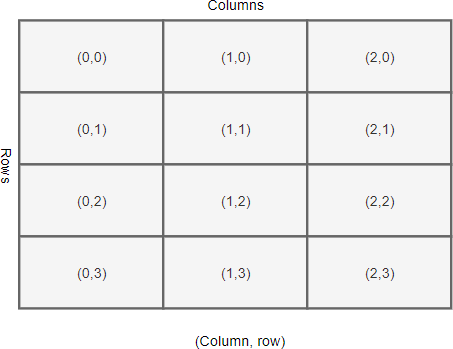

The intersection of a row and a column is called a cell. A cell is an area that you can place a widget. A cell can hold only one widget. If you place two widgets in a cell, they will be on top of each other.

To place multiple widgets in a cell, you use a Frame or LabelFrame to wrap the widgets and place the Frame or LabelFrame on the cell.

The width of a column depends on the width of the widget it contains. Similarly, the height of a row depends on the height of the widgets contained within the row.

Rows and columns can span. The following illustrates a grid that has the cell (1,1) that spans two columns and the cell (0,2) that spans two rows:

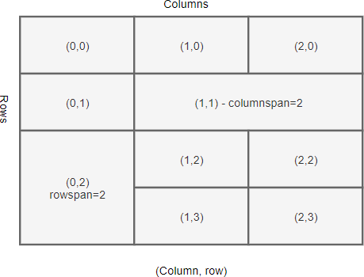

#### widget.grid(**options)

The grid() method has the following parameters:

[output not shown]

##### Sticky:

By default, when a cell is larger than the widget it contains, the grid geometry manager places the widget at the center of the cell horizontally and vertically. To change this default behavior, you can use the sticky option. The sticky option specifies which edge of the cell the widget should stick to.

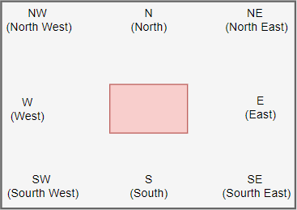

##### Padding:

To add paddings between cells of a grid, you use the padx and pady options. The padx and pady are external paddings. To add paddings within a widget itself, you use ipadx and ipady options. The ipadx and ipady are internal paddings.

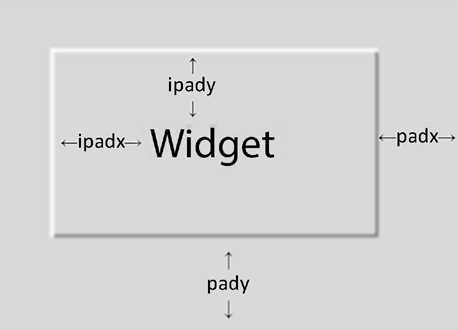

#### Example 1

```python
import tkinter as tk

# creating main tkinter window/toplevel
master = tk.Tk()

# this will create a label widget
l1 = tk.Label(master, text = "First:")
l2 = tk.Label(master, text = "Second:")

# grid method to arrange labels in respective
# rows and columns as specified
l1.grid(row = 0, column = 0, sticky = tk.E, pady = 2, padx =2)
l2.grid(row = 1, column = 0, sticky = tk.E, pady = 10, padx = 2)

# entry widgets, used to take entry from user
e1 = tk.Entry(master)
e2 = tk.Entry(master)

# this will arrange entry widgets
e1.grid(row = 0, column = 1, pady = 2, padx =10)
e2.grid(row = 1, column = 1, pady = 2, padx =10)

# infinite loop which can be terminated by keyboard
# or mouse interrupt
tk.mainloop()
```

## ATTENTION!!!

The configure() method can be called on any Tkinter widget to change its properties. It accepts the same keyword arguments as the widget's constructor.

## Tkinter control variables: Retrieving data from our widgets

four types of control variables:

```
tk.StringVar(): Used to store strings of any length
tk.IntVar(): Used to store integers
tk.DoubleVar(): Used to store floating-point values
tk.BooleanVar(): Used to store Boolean (True/False) values
```

#### Why we need control variables?

We can create a two-way binding between a control variable and a widget, so that if either the widget contents are changed or the variable contents are changed, both will be kept in sync.

#### Note that no control variable objects can be created until a Tk object exists

#### Example:

```python
import tkinter as tk

# creating main tkinter window/toplevel
root = tk.Tk()

name_var = tk.StringVar(root)
# this will create a label widget
l1 = tk.Label(root, text = "Name:")
l1.grid(row = 0, column = 0, sticky = tk.E, pady = 2, padx =2)
e1 = tk.Entry(root,textvariable=name_var)
e1.grid(row = 0, column = 1, pady = 2, padx =10)

tk.mainloop()
```

By doing this, the contents of the e1 widget and the name_var variable are kept in sync. A call to the variable's get() method will return the current contents of the box:

```python
print(name_var.get())
```

```
nfsdfjisd kfdslkg
```

## Making the GUI actually do something

The GUI cannot simply execute all the code from top to bottom. Instead, it has to respond to user actions, such as a button click or a keystroke, whenever and in whatever order they happen. Such actions are known as events. To make the program respond to an event, we need to bind the event to a function, which we call a callback. We use the control variables in the callback functions to access the user inputs.

There are a few ways to bind events to callback functions in Tkinter:

```
   1. command argument: when creating a widget (for example, submit_btn = tk.Button(root, command=on_submit))
   2. configure() method: after creation of the widget (for example, submit_btn.configure(command=on_submit))
   3. Using the bind() method (for example submit_btn.bind(sequence=<Button>, func=on_submit))
```

### Using the command option

command specifies a reference to a callback function to be called when the button is clicked. Note that we do not put parentheses after the function name here; doing so would cause the function to be called and its return value would be assigned to command. We only want a reference to the function here. The callback function needs to exist before we can pass it to command.

##### Examples:

```python
import tkinter as tk

root = tk.Tk()
root.geometry("400x200")

def on_submit() :
    print('Submit button is clicked.')

button_submit = tk.Button(root, text ="Submit", command=on_submit)
button_submit.pack()

root.mainloop()
```

```
Submit button is clicked.
Submit button is clicked.
Submit button is clicked.
Submit button is clicked.
```

```python
import tkinter as tk

root = tk.Tk()
l1=tk.Label(root,text='sample',bg='blue', fg= "white", height=5,width=20)
l1.grid(row=0,column=0,columnspan=3,padx=20,pady=20)

r_str = tk.StringVar()  # string variable
r_str.set('first')     # Can assign value Appear or Failed

def on_select():
    choice = "You selected " + r_str.get() +" Choice"
    l1.config(text=choice)

r1 = tk.Radiobutton(root, text='First', variable=r_str, value='first', command = on_select)
r1.grid(row=1,column=0)

r2 = tk.Radiobutton(root, text='Second', variable=r_str, value ='second', command = on_select)
r2.grid(row=1,column=1)

r3 = tk.Radiobutton(root, text='Third', variable=r_str, value='third', command = on_select)
r3.grid(row=1,column=2)

root.mainloop()  # Keep the window open
```

### Using the bind method

Tkinter uses so-called "event sequences" for allowing the user to define which events, both specific and general, he or she wants to bind to handlers. It is the first argument "event" of the bind method.

List of most common events:

\<Button> − Use the Button event in a handler for binding the Mouse wheels and Buttons.

\<ButtonRelease> − Instead of clicking a Button, you can also trigger an event by releasing the mouse buttons.

\<Enter>, <\Return> − Start the process or call an event by pressing enter or return key.

\<Key Press> − Start the process or call the handler by pressing the key.

\<KeyRelease> − Start the process or call an event by releasing a key.

##### Example:

```python
import tkinter as tk


root= tk.Tk()
root.geometry("100x100")

def display_text(event):
   label.config(text="You asked for it!")

# Create a label widget to add some text
label= tk.Label(root, text= "")
label.pack()

button= tk.Button(root, text= "reveal hidden text?")
button.pack()
button.bind('<Button>',display_text)

root.mainloop()
```